# Package Pandas

**pandas** est un package python spécialisé sur la gestion/manipulation des tables de données. Dans ce cours, nous allons apprendre à :

- Installer/charger le package pandas
- Créer des tables de données python appelées des **dataframes**
- Manipuler des dataframes
- Sauvegarder des dataframes sous plusieurs formats (excel, csv, json...)

# Installation du package pandas

Pour installer le package pandas, il faut utiliser le code suivant :

- Si vous êtes sur jupyter notebook : **!pip install pandas**

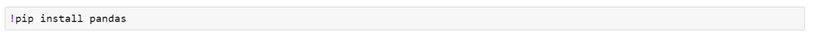

```python
!pip install pandas
```

- Si vous utilisez un **Terminal** : **pip install pandas**

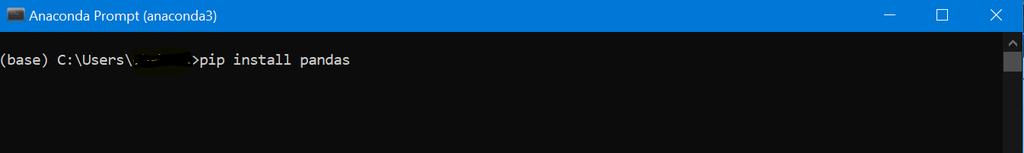

## Charger le package pandas dans le kernel python

Pour charger le pachage, il faut lancer la ligne de code : **import pandas**

Vous pouvez également écrire : **import pandas as pd.

- **as** permet d'ajouter un alias au package.
- alias le plus utilisé pour le package pandas dans la communauté python est **pd**

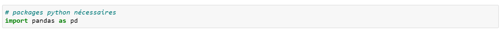

```python
# packages python nécessaires
import pandas as pd
```

# Création des dataframes

La création des dataframes peut se faire de plusieurs façons. Soit à partir des :

- **Dictionnaires**
- **Séries** (autres types d'objets propres au package pandas),
- **Tableaux**
- **Fichiers**.

## Création de dataframe à partir de dicitonnaires

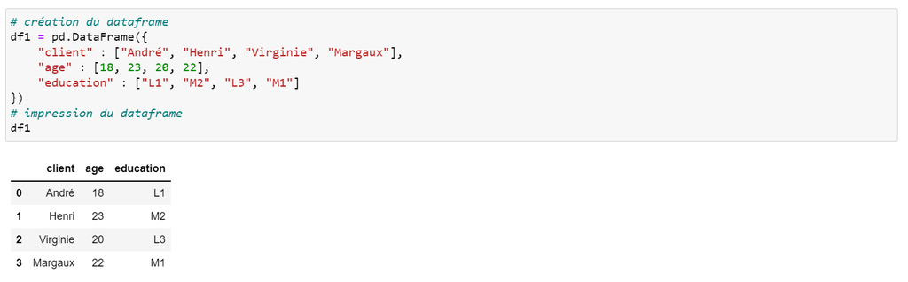

```python
# création du dataframe
df1 = pd.DataFrame({
    "client" : ["André", "Henri", "Virginie", "Margaux"],
    "age" : [18, 23, 20, 22],
    "education" : ["L1", "M2", "L3", "M1"]
})
# impression du dataframe
df1
```

|  | client | age | education |
| --- | --- | --- | --- |
| 0 | André | 18 | L1 |
| 1 | Henri | 23 | M2 |
| 2 | Virginie | 20 | L3 |
| 3 | Margaux | 22 | M1 |

## Création des dataframes à partir de séries

Les séries sont des objets python qui sont proches des listes. Il correspond à un vecteur colonne. On peut créer ce type de données à partir de liste ou de dictionnaires.

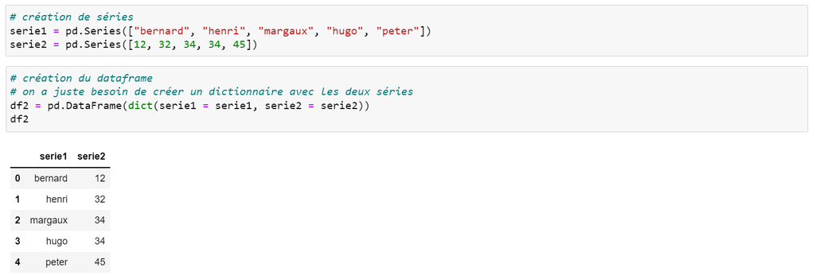

```python
# création de séries
serie1 = pd.Series(["bernard", "henri", "margaux", "hugo", "peter"])
serie2 = pd.Series([12, 32, 34, 34, 45])
```

```python
# création du dataframe
# on a juste besoin de créer un dictionnaire avec les deux séries
df2 = pd.DataFrame(dict(serie1 = serie1, serie2 = serie2))
df2
```

|  | serie1 | serie2 |
| --- | --- | --- |
| 0 | bernard | 12 |
| 1 | henri | 32 |
| 2 | margaux | 34 |
| 3 | hugo | 34 |
| 4 | peter | 45 |

## Lire un fichier avec pandas

Les fichiers concernés ont la forme des tables de données. Cela peut peut être des ficihers excel ou des csv par exemple. Pour créer le dataframe on va procéder par l'importation des fichiers à l'aide du package pandas.

### Fichiers CSV

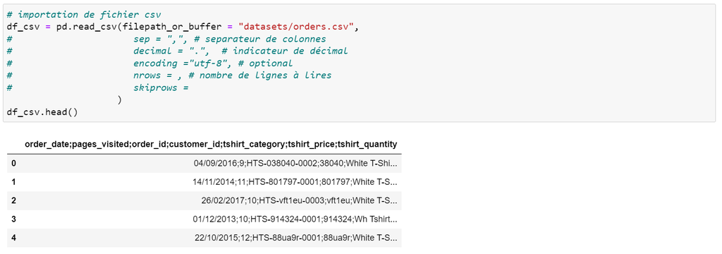

```python
# importation de fichier csv
df_csv = pd.read_csv(filepath_or_buffer = "datasets/orders.csv",
#                      sep = ",", # separateur de colonnes
#                      decimal = ".",  # indicateur de décimal
#                      encoding ="utf-8", # optional
#                      nrows = , # nombre de lignes à lires
#                      skiprows =
                    )
df_csv.head()
```

|  | order_date;pages_visited;order_id;customer_id;tshirt_category;tshirt_price;tshirt_quantity |
| --- | --- |
| 0 | 04/09/2016;9;HTS-038040-0002;38040;White T-Shi... |
| 1 | 14/11/2014;11;HTS-801797-0001;801797;White T-S... |
| 2 | 26/02/2017;10;HTS-vft1eu-0003;vft1eu;White T-S... |
| 3 | 01/12/2013;10;HTS-914324-0001;914324;Wh Tshirt... |
| 4 | 22/10/2015;12;HTS-88ua9r-0001;88ua9r;White T-S... |

Nous remarquons ici que, le DataFrame obtenu en sorti comporte une seule colonne avec des textes séparés par un **;**. Nous allons donc ajouter à notre fonction un séparateur.

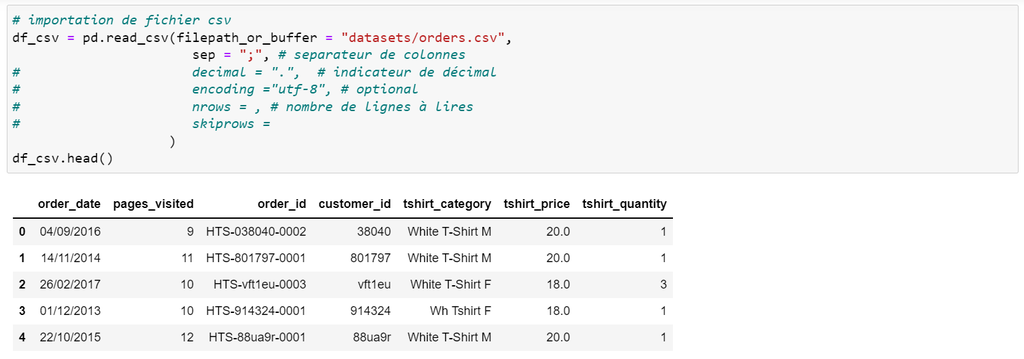

```python
# importation de fichier csv
df_csv = pd.read_csv(filepath_or_buffer = "datasets/orders.csv",
                       sep = ";", # separateur de colonnes
#                      decimal = ".",  # indicateur de décimal
#                      encoding ="utf-8", # optional
#                      nrows = , # nombre de lignes à lires
#                      skiprows =
                    )
df_csv.head()
```

|  | order_date | pages_visited | order_id | customer_id | tshirt_category | tshirt_price | tshirt_quantity |
| --- | --- | --- | --- | --- | --- | --- | --- |
| 0 | 04/09/2016 | 9 | HTS-038040-0002 | 38040 | White T-Shirt M | 20.0 | 1 |
| 1 | 14/11/2014 | 11 | HTS-801797-0001 | 801797 | White T-Shirt M | 20.0 | 1 |
| 2 | 26/02/2017 | 10 | HTS-vft1eu-0003 | vft1eu | White T-Shirt F | 18.0 | 3 |
| 3 | 01/12/2013 | 10 | HTS-914324-0001 | 914324 | Wh Tshirt F | 18.0 | 1 |
| 4 | 22/10/2015 | 12 | HTS-88ua9r-0001 | 88ua9r | White T-Shirt M | 20.0 | 1 |

### Fichiers xlsx

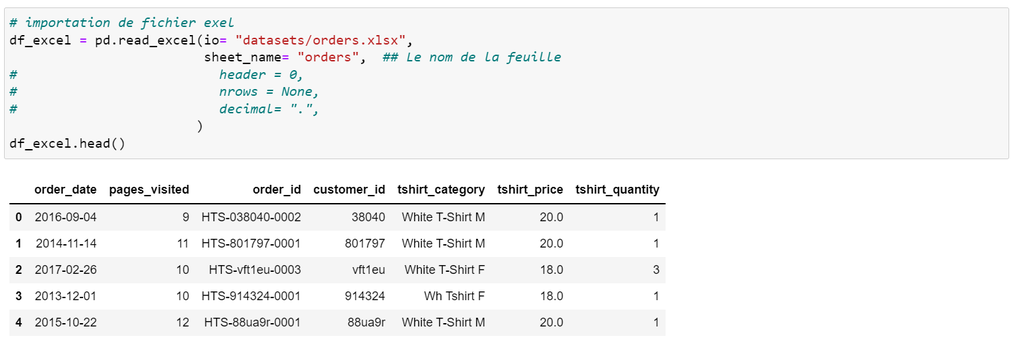

```python
# importation de fichier exel
df_excel = pd.read_excel(io= "datasets/orders.xlsx",
                         sheet_name= "orders",  ## Le nom de la feuille
#                          header = 0,
#                          nrows = None,
#                          decimal= ".",
                        )
df_excel.head()
```

|  | order_date | pages_visited | order_id | customer_id | tshirt_category | tshirt_price | tshirt_quantity |
| --- | --- | --- | --- | --- | --- | --- | --- |
| 0 | 2016-09-04 | 9 | HTS-038040-0002 | 38040 | White T-Shirt M | 20.0 | 1 |
| 1 | 2014-11-14 | 11 | HTS-801797-0001 | 801797 | White T-Shirt M | 20.0 | 1 |
| 2 | 2017-02-26 | 10 | HTS-vft1eu-0003 | vft1eu | White T-Shirt F | 18.0 | 3 |
| 3 | 2013-12-01 | 10 | HTS-914324-0001 | 914324 | Wh Tshirt F | 18.0 | 1 |
| 4 | 2015-10-22 | 12 | HTS-88ua9r-0001 | 88ua9r | White T-Shirt M | 20.0 | 1 |

# Comment obtenir des informations sur un dataframe ? 🧐🧐

```python
Nous allons affichés un nombre définit de notre DataFrame
```

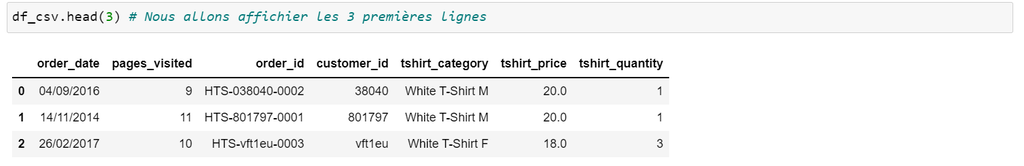

```python
df_csv.head(3) # Nous allons affichier les 3 premières lignes
```

|  | order_date | pages_visited | order_id | customer_id | tshirt_category | tshirt_price | tshirt_quantity |
| --- | --- | --- | --- | --- | --- | --- | --- |
| 0 | 04/09/2016 | 9 | HTS-038040-0002 | 38040 | White T-Shirt M | 20.0 | 1 |
| 1 | 14/11/2014 | 11 | HTS-801797-0001 | 801797 | White T-Shirt M | 20.0 | 1 |
| 2 | 26/02/2017 | 10 | HTS-vft1eu-0003 | vft1eu | White T-Shirt F | 18.0 | 3 |

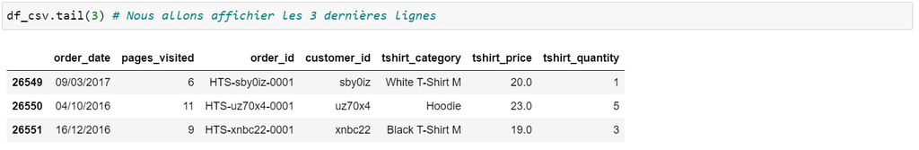

```python
df_csv.tail(3) # Nous allons affichier les 3 dernières lignes
```

|  | order_date | pages_visited | order_id | customer_id | tshirt_category | tshirt_price | tshirt_quantity |
| --- | --- | --- | --- | --- | --- | --- | --- |
| 26549 | 09/03/2017 | 6 | HTS-sby0iz-0001 | sby0iz | White T-Shirt M | 20.0 | 1 |
| 26550 | 04/10/2016 | 11 | HTS-uz70x4-0001 | uz70x4 | Hoodie | 23.0 | 5 |
| 26551 | 16/12/2016 | 9 | HTS-xnbc22-0001 | xnbc22 | Black T-Shirt M | 19.0 | 3 |

Déterminons le nombre de ligne et de colonne de notre DataFrame

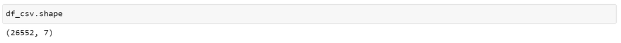

```python
df_csv.shape
```

```
(26552, 7)
```

Obtenir la liste des colonnes, le nombre de valeurs non renseignées, le type de données de la colonne.

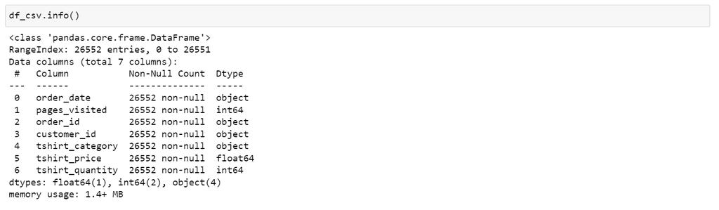

```python
df_csv.info()
```

```
<class 'pandas.core.frame.DataFrame'>
RangeIndex: 26552 entries, 0 to 26551
Data columns (total 7 columns):
 #   Column           Non-Null Count  Dtype
---  ------           --------------  -----
 0   order_date       26552 non-null  object
 1   pages_visited    26552 non-null  int64
 2   order_id         26552 non-null  object
 3   customer_id      26552 non-null  object
 4   tshirt_category  26552 non-null  object
 5   tshirt_price     26552 non-null  float64
 6   tshirt_quantity  26552 non-null  int64
dtypes: float64(1), int64(2), object(4)
memory usage: 1.4+ MB
```

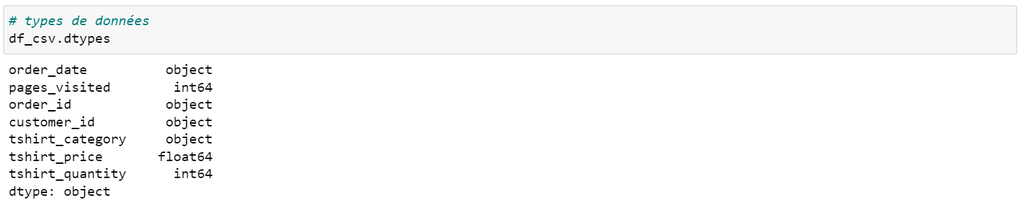

```python
# types de données
df_csv.dtypes
```

```
order_date          object
pages_visited        int64
order_id            object
customer_id         object
tshirt_category     object
tshirt_price       float64
tshirt_quantity      int64
dtype: object
```

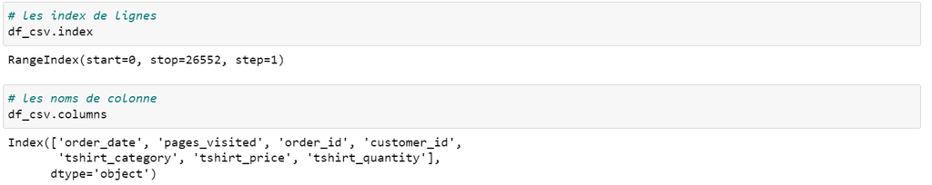

```python
# les index de lignes
df_csv.index
```

```
RangeIndex(start=0, stop=26552, step=1)
```

```python
# les noms de colonne
df_csv.columns
```

```
Index(['order_date', 'pages_visited', 'order_id', 'customer_id',
       'tshirt_category', 'tshirt_price', 'tshirt_quantity'],
      dtype='object')
```

## La concaténation des dataframe

Pour concaténer deux DataFrames, on utilise **concat**

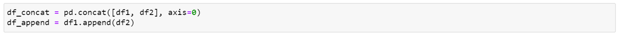

```python
df_concat = pd.concat([df1, df2], axis=0)
df_append = df1.append(df2)
```

## Fusion de deux ou plusieurs DataFrames

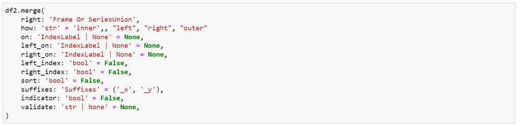

```python
df2.merge(
    right: 'Frame Or SeriesUnion',
    how: 'str' = 'inner',, "left", "right", "outer"
    on: 'IndexLabel | None' = None,
    left_on: 'IndexLabel | None' = None,
    right_on: 'IndexLabel | None' = None,
    left_index: 'bool' = False,
    right_index: 'bool' = False,
    sort: 'bool' = False,
    suffixes: 'Suffixes' = ('_x', '_y'),
    indicator: 'bool' = False,
    validate: 'str | None' = None,
)
```

# Trier, grouper, application des fonctions custom sur des dataframes

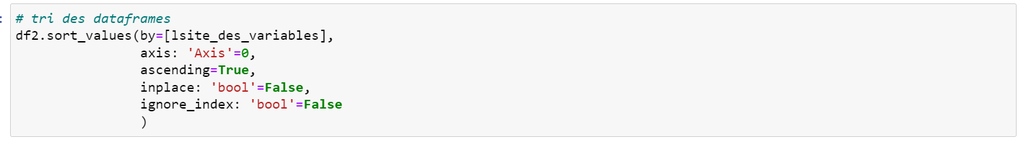

```python
# tri des dataframes
df2.sort_values(by=[lsite_des_variables],
                axis: 'Axis'=0,
                ascending=True,
                inplace: 'bool'=False,
                ignore_index: 'bool'=False
                )
```

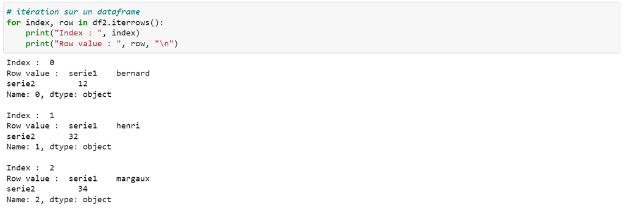

```python
# itération sur un dataframe
for index, row in df2.iterrows():
    print("Index : ", index)
    print("Row value : ", row, "\n")
```

```
Index :  0
Row value :  serie1    bernard
serie2         12
Name: 0, dtype: object

Index :  1
Row value :  serie1    henri
serie2       32
Name: 1, dtype: object

Index :  2
Row value :  serie1    margaux
serie2         34
Name: 2, dtype: object

Index :  3
Row value :  serie1    hugo
serie2      34
Name: 3, dtype: object

Index :  4
Row value :  serie1    peter
serie2       45
Name: 4, dtype: object
```

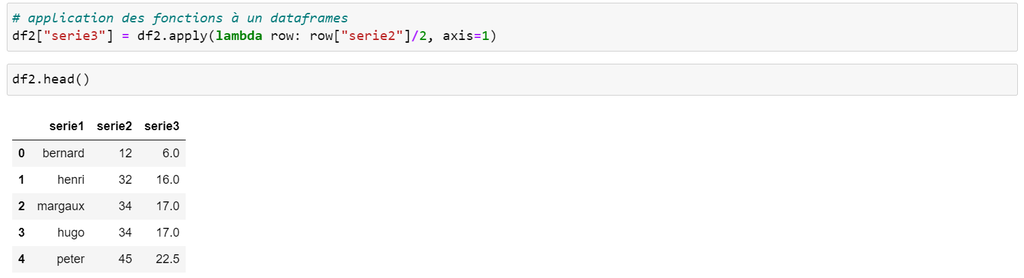

```python
# application des fonctions à un dataframes
df2["serie3"] = df2.apply(lambda row: row["serie2"]/2, axis=1)
```

```python
df2.head()
```

|  | serie1 | serie2 | serie3 |
| --- | --- | --- | --- |
| 0 | bernard | 12 | 6.0 |
| 1 | henri | 32 | 16.0 |
| 2 | margaux | 34 | 17.0 |
| 3 | hugo | 34 | 17.0 |
| 4 | peter | 45 | 22.5 |

[figure not shown]

```python
# les fonctions sur df
# sum, min, max, median, count, describe
df2.sum()
df2.min()
df2.max()
# df2.median()
# df2.describe()
```

[output not shown]

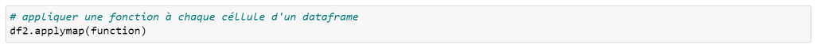

```python
# appliquer une fonction à chaque céllule d'un dataframe
df2.applymap(function)
```

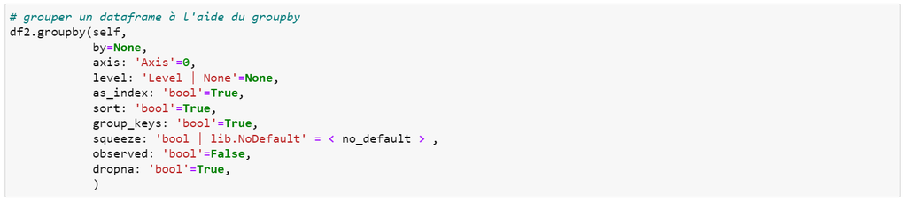

```python
# grouper un dataframe à l'aide du groupby
df2.groupby(self,
            by=None,
            axis: 'Axis'=0,
            level: 'Level | None'=None,
            as_index: 'bool'=True,
            sort: 'bool'=True,
            group_keys: 'bool'=True,
            squeeze: 'bool | lib.NoDefault' = < no_default > ,
            observed: 'bool'=False,
            dropna: 'bool'=True,
            )
```

# Sauvegarder les dataframes

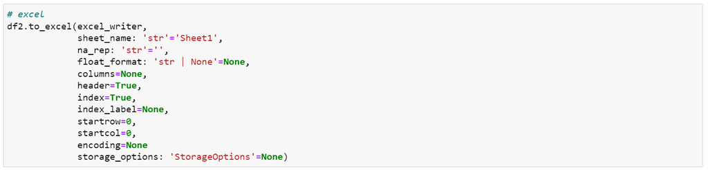

```python
# excel
df2.to_excel(excel_writer,
             sheet_name: 'str'='Sheet1',
             na_rep: 'str'='',
             float_format: 'str | None'=None,
             columns=None,
             header=True,
             index=True,
             index_label=None,
             startrow=0,
             startcol=0,
             encoding=None
             storage_options: 'StorageOptions'=None)
```

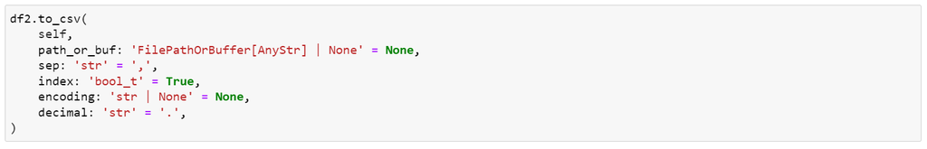

```python
df2.to_csv(
    self,
    path_or_buf: 'FilePathOrBuffer[AnyStr] | None' = None,
    sep: 'str' = ',',
    index: 'bool_t' = True,
    encoding: 'str | None' = None,
    decimal: 'str' = '.',
)
```

# Resources 📚📚

- Introduction à Panda : http://www.python-simple.com/python-pandas/panda-intro.php
- Maîtrisez l’analyse des données avec Pandas Python : https://www.data-transitionnumerique.com/panda-python/
- Pandas : le datamanagement à la portée de toutes les mains : https://www.invivoo.com/pandas-le-datamanagement-a-la-portee-de-toutes-les-mains/